# PART- A

### Part1.3e -Plot visuals as in Q3.C and share insights about difference observed in both the models

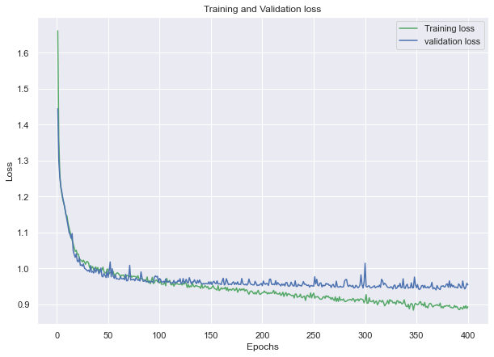

```python
loss_train = NNclassifier1.history['loss']
loss_val = NNclassifier1.history['val_loss']
epochs = range(1,401)
plt.plot(epochs, loss_train, 'g', label='Training loss')
plt.plot(epochs, loss_val, 'b', label='validation loss')
plt.title('Training and Validation loss')
plt.xlabel('Epochs')
plt.ylabel('Loss')
plt.legend()
plt.show()
```

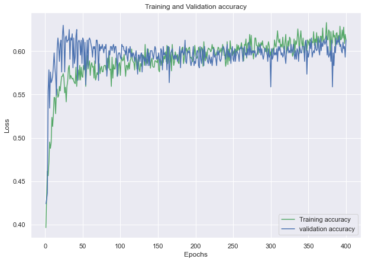

```python
loss_train = NNclassifier1.history['accuracy']
loss_val = NNclassifier1.history['val_accuracy']
epochs = range(1,401)
plt.plot(epochs, loss_train, 'g', label='Training accuracy')
plt.plot(epochs, loss_val, 'b', label='validation accuracy')
plt.title('Training and Validation accuracy')
plt.xlabel('Epochs')
plt.ylabel('Loss')
plt.legend()
plt.show()
```

### Difference observed in 2 models

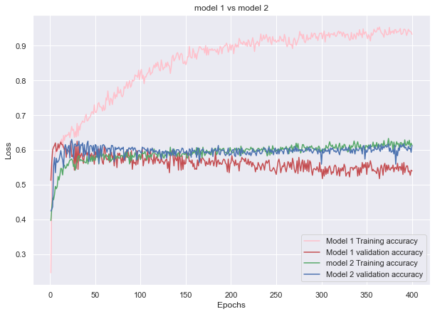

```python
m1loss_train = NNclassifier.history['accuracy']
m1loss_val = NNclassifier.history['val_accuracy']
m2loss_train = NNclassifier1.history['accuracy']
m2loss_val = NNclassifier1.history['val_accuracy']
epochs = range(1,401)
plt.plot(epochs, m1loss_train, 'pink', label='Model 1 Training accuracy')
plt.plot(epochs, m1loss_val, 'r', label='Model 1 validation accuracy')
plt.plot(epochs, m2loss_train, 'g', label='model 2 Training accuracy')
plt.plot(epochs, m2loss_val, 'b', label='Model 2 validation accuracy')
plt.title('model 1 vs model 2')
plt.xlabel('Epochs')
plt.ylabel('Loss')
plt.legend()
plt.show()
```

From the above plot,

model 2 - Model is not overfit , from model 1 there is 10% increase in validation accuracy. [ Due to imbalanced target variables accuracy falls under 60% ]

Trying Neural network regressor to solve the same problem.

### Design a Neural Network to train a Regression

### The need is to build a regressor which can use these parameters to determine the signal strength or quality [as number]

*First training regressor as asked in project objective with X and y not transformed as categorical*

```python
NN_model_Regressor = tf.keras.models.Sequential()

# The Input Layer :
NN_model_Regressor.add(tf.keras.layers.Dense(128, kernel_initializer='normal',input_dim = X_train.shape[1], activation='relu'))

# The Hidden Layers :
NN_model_Regressor.add(tf.keras.layers.Dense(64, kernel_initializer='normal',activation='tanh'))

NN_model_Regressor.add(tf.keras.layers.Dense(32, kernel_initializer='normal'))
NN_model_Regressor.add(tf.keras.layers.Dropout(0.2))

NN_model_Regressor.add(tf.keras.layers.Dense(16, kernel_initializer='normal'))
NN_model_Regressor.add(tf.keras.layers.Dropout(0.2))


# The Output Layer :
NN_model_Regressor.add(tf.keras.layers.Dense(1, kernel_initializer='normal'))

# Compile the network :
NN_model_Regressor.compile(loss='mse', optimizer='sgd')
NN_model_Regressor.summary()
```

```
Model: "sequential_2"
_________________________________________________________________
Layer (type)                 Output Shape              Param #
=================================================================
dense_10 (Dense)             (None, 128)               1536
_________________________________________________________________
dense_11 (Dense)             (None, 64)                8256
_________________________________________________________________
dense_12 (Dense)             (None, 32)                2080
_________________________________________________________________
dropout_2 (Dropout)          (None, 32)                0
_________________________________________________________________
dense_13 (Dense)             (None, 16)                528
_________________________________________________________________
dropout_3 (Dropout)          (None, 16)                0
_________________________________________________________________
dense_14 (Dense)             (None, 1)                 17
=================================================================
Total params: 12,417
Trainable params: 12,417
Non-trainable params: 0
_________________________________________________________________
```

```python
EPOCH=400
Network_Regressor=NN_model_Regressor.fit(X_Train_S, Y_train, validation_data=(X_Test_S,Y_test), epochs=EPOCH, batch_size=200)
```

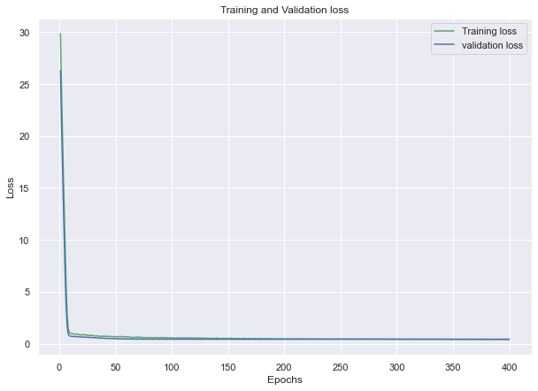

```python
loss_train = Network_Regressor.history['loss']
loss_val = Network_Regressor.history['val_loss']
epochs = range(1,EPOCH+1)
plt.plot(epochs, loss_train, 'g', label='Training loss')
plt.plot(epochs, loss_val, 'b', label='validation loss')
plt.title('Training and Validation loss')
plt.xlabel('Epochs')
plt.ylabel('Loss')
plt.legend()
plt.show()
```

Model Evaluation

```python
ynew= NN_model_Regressor.predict(X_Test_S)

Xnew = scale.inverse_transform(X_Test_S)
print("X=%s, Predicted=%s" % (Xnew[0], ynew[0]))
```

```
X=[11.5     0.59    0.59    2.6     0.087  13.     49.      0.9988  3.18
  0.65   11.    ], Predicted=[5.7549114]
```

```python
TestData=pd.DataFrame(data=X_test)
TestData['signalstrength']=Y_test
TestData['Predictedsignalstrength']=ynew
TestData['Predictedsignalstrength']=round(TestData['Predictedsignalstrength'])
TestData['Predictedsignalstrength']=TestData['Predictedsignalstrength'].astype(int)
TestData.head()
```

|  | Parameter 1 | Parameter 2 | Parameter 3 | Parameter 4 | Parameter 5 | Parameter 6 | Parameter 7 | Parameter 8 | Parameter 9 | Parameter 10 | Parameter 11 | signalstrength | Predictedsignalstrength |
| --- | --- | --- | --- | --- | --- | --- | --- | --- | --- | --- | --- | --- | --- |
| 397 | 11.50 | 0.59 | 0.59 | 2.60 | 0.087 | 13.0 | 49.0 | 0.99880 | 3.180 | 0.65 | 11.0 | 6 | 6 |
| 1071 | 7.50 | 0.77 | 0.20 | 3.65 | 0.098 | 30.0 | 92.0 | 0.99892 | 3.200 | 0.58 | 9.2 | 5 | 5 |
| 440 | 12.35 | 0.31 | 0.72 | 2.20 | 0.072 | 6.0 | 29.0 | 0.99870 | 2.925 | 0.82 | 9.8 | 8 | 6 |
| 219 | 7.80 | 0.53 | 0.33 | 2.40 | 0.080 | 24.0 | 124.5 | 0.99655 | 3.300 | 0.60 | 9.5 | 5 | 5 |
| 613 | 8.20 | 0.39 | 0.38 | 1.50 | 0.058 | 10.0 | 29.0 | 0.99620 | 3.260 | 0.74 | 9.8 | 5 | 6 |

```python
APE=100*(abs(TestData['signalstrength']-TestData['Predictedsignalstrength'])/TestData['signalstrength'])
TestData['APE']=APE

print('The Accuracy  is:', 100-np.mean(APE))
TestData.head()
```

```
The Accuracy  is: 92.73459383753502
```

|  | Parameter 1 | Parameter 2 | Parameter 3 | Parameter 4 | Parameter 5 | Parameter 6 | Parameter 7 | Parameter 8 | Parameter 9 | Parameter 10 | Parameter 11 | signalstrength | Predictedsignalstrength | APE |
| --- | --- | --- | --- | --- | --- | --- | --- | --- | --- | --- | --- | --- | --- | --- |
| 397 | 11.50 | 0.59 | 0.59 | 2.60 | 0.087 | 13.0 | 49.0 | 0.99880 | 3.180 | 0.65 | 11.0 | 6 | 6 | 0.0 |
| 1071 | 7.50 | 0.77 | 0.20 | 3.65 | 0.098 | 30.0 | 92.0 | 0.99892 | 3.200 | 0.58 | 9.2 | 5 | 5 | 0.0 |
| 440 | 12.35 | 0.31 | 0.72 | 2.20 | 0.072 | 6.0 | 29.0 | 0.99870 | 2.925 | 0.82 | 9.8 | 8 | 6 | 25.0 |
| 219 | 7.80 | 0.53 | 0.33 | 2.40 | 0.080 | 24.0 | 124.5 | 0.99655 | 3.300 | 0.60 | 9.5 | 5 | 5 | 0.0 |
| 613 | 8.20 | 0.39 | 0.38 | 1.50 | 0.058 | 10.0 | 29.0 | 0.99620 | 3.260 | 0.74 | 9.8 | 5 | 6 | 20.0 |

1. Pickle the model for future use

```python
from tensorflow.keras.models import model_from_json
import numpy
import os

# Pickle model to JSON
Regressor_model_json = NN_model_Regressor.to_json()
with open("Regressor_model.json", "w") as json_file:
    json_file.write(Regressor_model_json)
# Pickle weights to HDF5
NN_model_Regressor.save_weights("Regressor_model.h5")
print("Saved model to disk")


# load json and create model
json_file = open('Regressor_model.json', 'r')
loaded_model_json = json_file.read()
json_file.close()
loaded_model = model_from_json(loaded_model_json)
# load weights into new model
loaded_model.load_weights("Regressor_model.h5")
print("Loaded model from disk")

# Evaluate
loaded_model.compile(loss='mse', optimizer='adam',metrics=['mse'])
loss = loaded_model.evaluate(X_Test_S,Y_test, verbose=0)
print("%s: %.2f" % (loaded_model.metrics_names[1], loss[1]))
```

```
Saved model to disk
Loaded model from disk
mse: 0.43
```

# Part-B

DOMAIN: Autonomous Vehicles

• BUSINESS CONTEXT: A Recognising multi-digit numbers in photographs captured at street level is an important component of modern-day map making. A classic example of a corpus of such street-level photographs is Google’s Street View imagery composed of hundreds of millions of geo-located 360-degree panoramic images. The ability to automatically transcribe an address number from a geo-located patch of pixels and associate the transcribed number with a known street address helps pinpoint, with a high degree of accuracy, the location of the building it represents. More broadly, recognising numbers in photographs is a problem of interest to the optical character recognition community. While OCR on constrained domains like document processing is well studied, arbitrary multi-character text recognition in photographs is still highly challenging. This difficulty arises due to the wide variability in the visual appearance of text in the wild on account of a large range of fonts, colours, styles, orientations, and character arrangements. The recognition problem is further complicated by environmental factors such as lighting, shadows, specularity, and occlusions as well as by image acquisition factors such as resolution, motion, and focus blurs. In this project, we will use the dataset with images centred around a single digit (many of the images do contain some distractors at the sides). Although we are taking a sample of the data which is simpler, it is more complex than MNIST because of the distractors.

• DATA DESCRIPTION: The SVHN is a real-world image dataset for developing machine learning and object recognition algorithms with the minimal requirement on data formatting but comes from a significantly harder, unsolved, real-world problem (recognising digits and numbers in natural scene images). SVHN is obtained from house numbers in Google Street View images. Where the labels for each of this image are the prominent number in that image i.e. 2,6,7 and 4 respectively.The dataset has been provided in the form of h5py files.

• PROJECT OBJECTIVE: We will build a digit classifier on the SVHN (Street View Housing Number) datase

```python
import h5py
```

### Part2.1a-Read the .h5 file and assign to a variable.

```python
# Read the h5 file
h5_SVH = h5py.File('Autonomous_Vehicles_SVHN_single_grey1.h5', 'r')
```

### Part2.1b-Print all the keys from the .h5 file

```python
h5_SVH.keys()
```

```
<KeysViewHDF5 ['X_test', 'X_train', 'X_val', 'y_test', 'y_train', 'y_val']>
```

### Part2.1c-Split the data into X_train, X_test, Y_train, Y_test

```python
# Load the training, validation and test sets
X_train = h5_SVH['X_train'][:]
y_train_o = h5_SVH['y_train'][:]
X_val = h5_SVH['X_val'][:]
y_val_o = h5_SVH['y_val'][:]
X_test = h5_SVH['X_test'][:]
y_test_o = h5_SVH['y_test'][:]

# Close this file

h5_SVH.close()
```

### Part2.2a-Print shape of all the 4 data split into x, y, train, test to verify if x & y is in sync.

```python
print('Training set', X_train.shape, y_train_o.shape)
print('Validation set', X_val.shape, y_val_o.shape)
print('Test set', X_test.shape, y_test_o.shape)

print('\n')
print('Unique labels in y_train:', np.unique(y_train_o))
print('Unique labels in y_val:', np.unique(y_val_o))
print('Unique labels in y_test:', np.unique(y_test_o))
```

```
Training set (42000, 32, 32) (42000,)
Validation set (60000, 32, 32) (60000,)
Test set (18000, 32, 32) (18000,)


Unique labels in y_train: [0 1 2 3 4 5 6 7 8 9]
Unique labels in y_val: [0 1 2 3 4 5 6 7 8 9]
Unique labels in y_test: [0 1 2 3 4 5 6 7 8 9]
```

```python
if (X_train.shape[1]== X_val.shape[1]==X_test.shape[1] and X_train.shape[2]== X_val.shape[2]==X_test.shape[2]):
    print('Train , Test and Validation set are in Synch')
else :
    print('Train , Test and Validation set are not in Synch')
```

```
Train , Test and Validation set are in Synch
```

### Part2.2b-Visualise first 10 images in train data and print its corresponding labels.

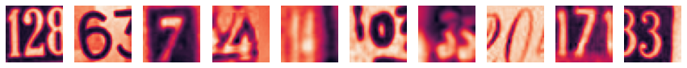

```
Label for each of the above image: [2 6 7 4 4 0 3 0 7 3]
```

```python
# Visualizing first 10 images in the dataset and their labels
plt.figure(figsize = (15, 4.5))
for i in range(10):
    plt.subplot(1, 10, i+1)
    plt.imshow(X_train[i].reshape((32, 32)))
    plt.axis('off')
plt.show()

print('Label for each of the above image: %s' % (y_train_o[0 : 10]))
```

```
First image
```

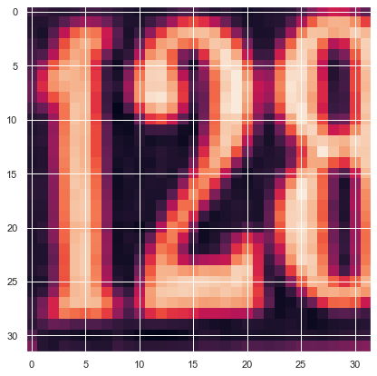

```
Label: 2
```

```python
print('First image');
plt.imshow(X_train[0])
plt.show()
print('Label:', y_train_o[0])
```

```
First image
```

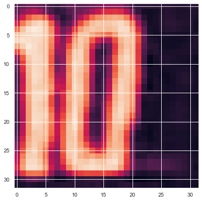

```
Label: 0
```

```python
print('First image');
plt.imshow(X_val[0])
plt.show()
print('Label:', y_val_o[0])
```

```
First image
```

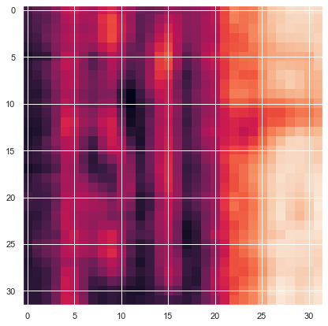

```
Label: 1
```

```python
print('First image');
plt.imshow(X_test[0])
plt.show()
print('Label:', y_test_o[0])
```

### Part2.2c-Reshape all the images with appropriate shape update the data in same variable

```python
print('Reshaping X data: (n, 32, 32) => (n, 1024)')
X_train = X_train.reshape((X_train.shape[0], -1))
X_val = X_val.reshape((X_val.shape[0], -1))
X_test = X_test.reshape((X_test.shape[0], -1))

print('Making sure that the values are float so that we can get decimal points after division');
X_train = X_train.astype('float32')
X_val = X_val.astype('float32')
X_test = X_test.astype('float32')
```

```
Reshaping X data: (n, 32, 32) => (n, 1024)
Making sure that the values are float so that we can get decimal points after division
```

### Part2.2d-Normalise the images i.e. Normalise the pixel value

```python
print('Normalizing')
X_train /= X_train.max()
X_val /= X_val.max()
X_test /= X_test.max()
print('After Normalization')
print(f'Min value is {X_train.min()}')
print(f'Max value is {X_train.max()}')
```

```
Normalizing
After Normalization
Min value is 0.0
Max value is 1.0
```

### Part2.2e-Transform Labels into format acceptable by Neural Network

```python
print('Converting y data into categorical (one-hot encoding)')
y_train = to_categorical(y_train_o)
y_val = to_categorical(y_val_o)
y_test = to_categorical(y_test_o)
print(f'Sample value after one hot encode {y_train[0]}')
```

```
Converting y data into categorical (one-hot encoding)
Sample value after one hot encode [0. 0. 1. 0. 0. 0. 0. 0. 0. 0.]
```

## Part2.2f-Print total Number of classes in the Dataset

```python
y_train.shape[1]
```

```
10
```

```python
len(y_train[0])
```

```
10
```

### Part2.3a-Design a Neural Network to train a classifier

```python
def model(iterations, lr, Lambda, verb=0, eval_test=False):
    scores=[]
    learning_rate=lr
    hidden_nodes=256
    output_nodes=10
    iterations=iterations
    # For early stopping of model.
    callbacks=tf.keras.callbacks.EarlyStopping(monitor='loss', patience=5)
    #model
    model = Sequential()
    model.add(Dense(500, input_shape=(1024,), activation='relu'))
    model.add(BatchNormalization())
    model.add(Dense(hidden_nodes,activation='relu'))
    model.add(Dense(hidden_nodes,activation='relu'))
    model.add(Dropout(0.5))
    model.add(Dense(hidden_nodes,activation='relu'))
    model.add(Dense(hidden_nodes,activation='relu'))
    model.add(Dropout(0.5))

    model.add(Dense(hidden_nodes,activation='relu'))
    model.add(Dense(hidden_nodes,activation='relu'))
    model.add(Dense(output_nodes, activation='softmax', kernel_regularizer=regularizers.l2(Lambda)))
    # adam optmizer with custom learning rate
    adam= optimizers.Adam(lr=learning_rate)
    #Compile the model
    model.compile(loss='categorical_crossentropy', optimizer=adam, metrics=['accuracy'])

    #Fit the model
    model.fit(X_train,y_train, validation_data=(X_val,y_val),epochs=iterations,
              batch_size=500, callbacks=[callbacks])

    if eval_test == True:
        score = model.evaluate(X_train,y_train, verbose=0)
        scores.append(score)
        score = model.evaluate(X_val,y_val, verbose=0)
        scores.append(score)
        score = model.evaluate(X_test,y_test, verbose=0)
        scores.append(score)
        return scores
    else:
        score = model.evaluate(X_val,y_val, verbose=(verb+1)%2)
        return score
```

### Part2.3b -Train the classifier using previously designed Architecture (Use best suitable parameters).

```python
iterations = 50
lr=1e-4
Lambda=1e-7
score=model(iterations, lr, Lambda)
print(f'Loss is {score[0]} and Accuracy is {score[1]}')
```

```
Loss is 0.45985475182533264 and Accuracy is 0.8617833256721497
```

```python
print(f'Loss is {score[0]} and Accuracy is {score[1]}')
```

[output not shown]

### Hyper parameter Tuning

```python
import math
results =[]
for i in range(10):

    lr=math.pow(10, np.random.uniform(-4.0,1.0))
    Lambda = math.pow(10, np.random.uniform(-7,-2))
    iterations = 25
    heading=f'Training {i+1} with learing rate {lr} and Lambda {Lambda}\n'
    print(heading)
    score=model(iterations, lr, Lambda)
    result=f'\n\nLoss is {score[0]} and Accuracy is {score[1]} with learing rate {lr} and Lambda {Lambda}\n\n\n'
    print(result)
    results.append(result)
```

```
Training 1 with learing rate 0.0979081229360113 and Lambda 0.006326106741408462



Loss is 3.9549221992492676 and Accuracy is 0.10000000149011612 with learing rate 0.0979081229360113 and Lambda 0.006326106741408462



Training 2 with learing rate 0.04828444224974756 and Lambda 0.00032728697441517716



Loss is 2.3181843757629395 and Accuracy is 0.10000000149011612 with learing rate 0.04828444224974756 and Lambda 0.00032728697441517716



Training 3 with learing rate 0.057869097719705935 and Lambda 0.0010540875773792017



Loss is 2.3658478260040283 and Accuracy is 0.10000000149011612 with learing rate 0.057869097719705935 and Lambda 0.0010540875773792017



Training 4 with learing rate 0.00033485191835621334 and Lambda 7.022527770152963e-06



Loss is 0.5941917896270752 and Accuracy is 0.8113999962806702 with learing rate 0.00033485191835621334 and Lambda 7.022527770152963e-06



Training 5 with learing rate 0.10754645466948967 and Lambda 0.000383265467262727



Loss is 2.491044282913208 and Accuracy is 0.10000000149011612 with learing rate 0.10754645466948967 and Lambda 0.000383265467262727



```

[output cut: 22 more lines]

```


Training 9 with learing rate 0.2827408778228054 and Lambda 0.00010070513297828094



Loss is 2.748732566833496 and Accuracy is 0.10000000149011612 with learing rate 0.2827408778228054 and Lambda 0.00010070513297828094



Training 10 with learing rate 0.00032685464127357 and Lambda 2.203737066328727e-07



Loss is 0.8379645943641663 and Accuracy is 0.7572500109672546 with learing rate 0.00032685464127357 and Lambda 2.203737066328727e-07
```

### Part2.3c-Evaluate performance of the model with appropriate metrics

[output not shown]

# Best Model

```python
iterations = 100
learning_rate=0.001
Lambda=0.007
hidden_nodes=256
output_nodes=10
# For early stopping of model.
callbacks=tf.keras.callbacks.EarlyStopping(monitor='loss', patience=5)
#model
model = Sequential()
model.add(Dense(250, input_shape=(1024,), activation='relu'))
model.add(BatchNormalization())
model.add(Dense(140,activation='relu'))
model.add(Dense(hidden_nodes,activation='relu'))
model.add(Dropout(0.5))
model.add(Dense(78,activation='relu'))
model.add(Dense(54,activation='relu'))
model.add(Dropout(0.5))

model.add(Dense(30,activation='relu'))
model.add(Dense(output_nodes, activation='softmax', kernel_regularizer=regularizers.l2(Lambda)))
# adam optmizer with custom learning rate
adam= optimizers.Adam(lr=learning_rate)
#Compile the model
model.compile(loss='categorical_crossentropy', optimizer=adam, metrics=['accuracy'])

#Fit the model
history=model.fit(X_train,y_train, validation_data=(X_val,y_val),epochs=iterations,
          batch_size=500, callbacks=[callbacks])

Trainscore = model.evaluate(X_train,y_train, verbose=0)
Valscore = model.evaluate(X_val,y_val, verbose=0)
Testscore = model.evaluate(X_test,y_test, verbose=0)

print("Trainscore",Trainscore)
print("Valscore",Valscore)
print("Testscore",Testscore)
```

```
Trainscore [0.5875841975212097, 0.8329285979270935]
Valscore [0.6688524484634399, 0.8173166513442993]
Testscore [0.8584780097007751, 0.7808889150619507]
```

```python
print('Testing the model on validation set dataset')
predictions = np.argmax(model.predict(X_val), axis=-1)
print('Classification Report'); print('--'*40)
print(classification_report(y_val_o, predictions))
```

```
Testing the model on validation set dataset
Classification Report
--------------------------------------------------------------------------------
              precision    recall  f1-score   support

           0       0.83      0.89      0.86      6000
           1       0.91      0.68      0.78      6000
           2       0.81      0.84      0.83      6000
           3       0.74      0.81      0.77      6000
           4       0.85      0.86      0.86      6000
           5       0.82      0.86      0.84      6000
           6       0.78      0.83      0.80      6000
           7       0.88      0.83      0.86      6000
           8       0.71      0.81      0.76      6000
           9       0.89      0.76      0.82      6000

    accuracy                           0.82     60000
   macro avg       0.82      0.82      0.82     60000
weighted avg       0.82      0.82      0.82     60000
```

```python
index = 0
misclassified_images = []
for label, predict in zip(y_val_o, predictions):
    if label != predict:
        misclassified_images.append(index)
    index +=1
print(misclassified_images)
print(len(misclassified_images))
```

[output not shown]

```
Was predicted  6
Was labeled  8
Predicted Probabilities:  [[0.02469414 0.00750988 0.00503525 0.00982411 0.01258796 0.02334872
  0.553176   0.00308912 0.35405433 0.00668051]]
```

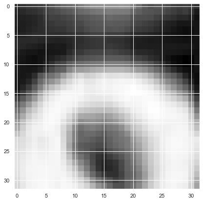

```python
image_index = 57388
plt.imshow(X_val[image_index].reshape(32, 32),cmap='Greys')
pred = model.predict(X_val[image_index].reshape(-1, 1024))
print("Was predicted ",pred.argmax())
print("Was labeled ",y_val_o[image_index])
print("Predicted Probabilities: ",pred)
```

### Part2.3d-Plot the training loss, validation loss vs number of epochs and training accuracy, validation accuracy vs number of epochs plot and write yourobservations on the same.

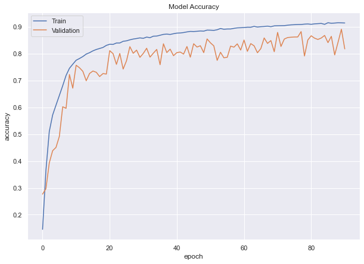

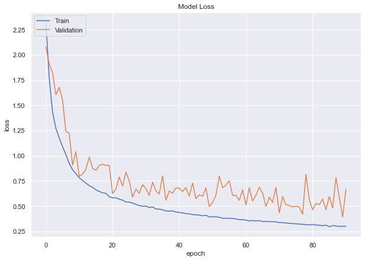

```python
# summarize history for accuracy
plt.plot(history.history['accuracy'])
plt.plot(history.history['val_accuracy'])
plt.title('Model Accuracy')
plt.ylabel('accuracy')
plt.xlabel('epoch')
plt.legend(['Train', 'Validation'], loc = 'upper left')
plt.show()
# summarize history for loss
plt.plot(history.history['loss'])
plt.plot(history.history['val_loss'])
plt.title('Model Loss')
plt.ylabel('loss')
plt.xlabel('epoch')
plt.legend(['Train', 'Validation'], loc = 'upper left')
plt.show()
```